# Chapter 3

R for physicians

2025-11-28

| Author |  |
| --- | --- |
| Name | Claire Descombes |
| Affiliation | Universitätsklinik für Neurochirurgie, Inselspital Bern |
| Degree | MSc Statistics and Data Science, University of Bern |
| Contact | claire.descombes@insel.ch |

The reference material for this course, as well as some useful literature to deepen your knowledge of R, can be found at the bottom of the page.

The base R plotting functions are effective and user-friendly, so we will begin by exploring their features.

Next, we will take a look at the functions offered by `ggplot2`, a system for declarative graphics creation. You provide the data and specify how to map variables to aesthetics and which graphical primitives to use; ggplot2 then takes care of the details. Although it is slightly more technical than base R, it produces very aesthetically pleasing results.

To explore R’s plotting capabilities, we’ll continue working with the NHANES datasets. Specifically, we’ll use the merged data frame that combines the `demo`, `bpx`, `bmx` and `smq` data sets. If you still have it loaded from Chapter 2, you can use it directly.

To be able to plot survival curves, we will also need survival data for the NHANES data set. Those can be found publicly as well (for adults only), on the [National Death Index](https://www.cdc.gov/nchs/linked-data/mortality-files/?CDC_AAref_Val=https://www.cdc.gov/nchs/data-linkage/mortality-public.htm). I already merged this survival data with the NHANES data set, please download it from the [`data_sets` folder](https://github.com/ClaireMargaux/rforphysicians/tree/main/data_sets) and import it into R.

```r
# Load the merged_nhanes CSV file
merged_nhanes <- read.csv("C:/GitHub/rforphysicians/data_sets/merged_nhanes.csv")

# Load the merged_nhanes_with_mort CSV file
merged_nhanes_with_mort <- read.csv("C:/GitHub/rforphysicians/data_sets/merged_nhanes_with_mort.csv")
```

# 1 Including plots using base R

## 1.1 Scatter plots

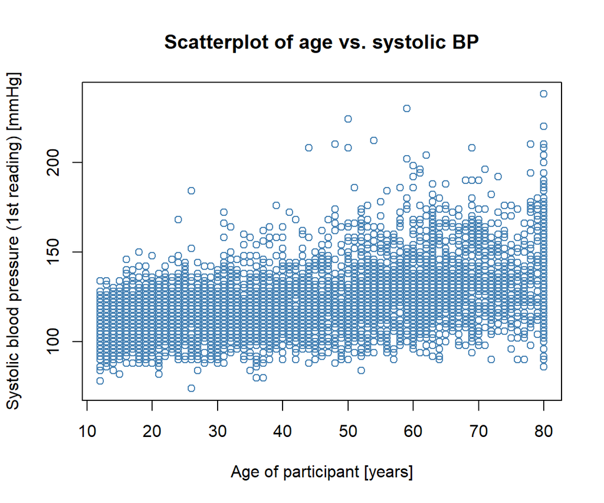

```r
plot(x = merged_nhanes$RIDAGEYR, y = merged_nhanes$BPXSY1,
     xlab = "Age of participant [years]",
     ylab = "Systolic blood pressure (1st reading) [mmHg]",
     main = "Scatterplot of age vs. systolic BP",
     col = c("steelblue"))
```

💡 The arguments `xlab` and `ylab` allow you to define a label for the x and y axes respectively. The argument `main` defines the main title of the plot.

## 1.2 Box plots

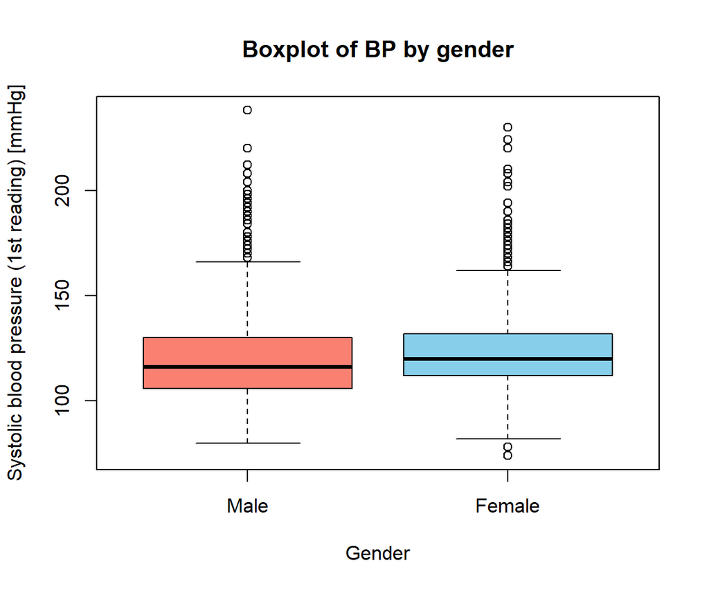

```r
boxplot(merged_nhanes$BPXSY1 ~ merged_nhanes$RIAGENDR,
        names = c("Male", "Female"),
        xlab = "Gender",
        ylab = "Systolic blood pressure (1st reading) [mmHg]",
        main = "Boxplot of BP by gender",
        col = c("salmon", "skyblue"))
```

## 1.3 Bar plots

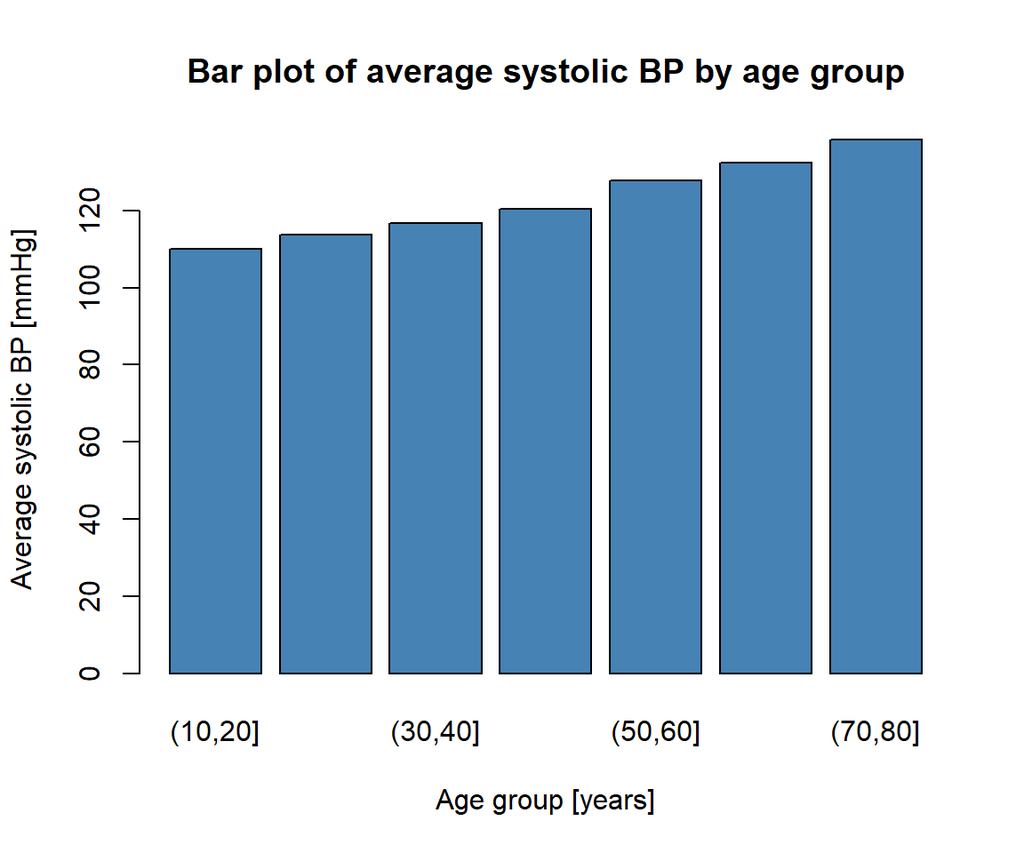

```r
# We define the age groups in which to calculate the mean systolic blood pressure and calculate the mean systolic blood pressure by age group
avg_bp <- merged_nhanes %>%
  filter(!is.na(BPXSY1), !is.na(RIDAGEYR)) %>%             # Remove NAs
  mutate(age_group = cut(RIDAGEYR, breaks = seq(10, 80, 10))) %>%  # Define age groups
  group_by(age_group) %>%
  summarise(mean_bp = mean(BPXSY1, na.rm = TRUE)) %>%
  ungroup()

barplot(height = avg_bp$mean_bp,
        names.arg = avg_bp$age_group,
        xlab = "Age group [years]",
        ylab = "Average systolic BP [mmHg]",
        main = "Bar plot of average systolic BP by age group",
        col = "steelblue")
```

💡 `cut()` divides the range of the imputed vector into intervals and codes its values according to which interval they fall. The leftmost interval corresponds to level one, the next leftmost to level two and so on.

## 1.4 Histograms

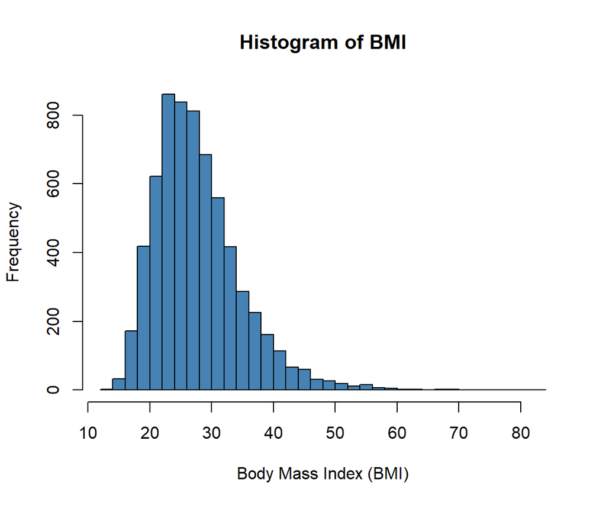

```r
hist(merged_nhanes$BMXBMI,
     breaks = 30,
     freq = TRUE,
     col = "steelblue",
     xlab = "Body Mass Index (BMI)",
     main = "Histogram of BMI")
```

💡 The argument `breaks` is a vector giving the breakpoints between histogram cells or a function to compute the vector of breakpoints.

💡 The argument `freq` is a logical: if TRUE, the histogram graphic is a representation of frequencies, the counts component of the result; if FALSE, probability densities, component density, are plotted.

## 1.5 Line plots

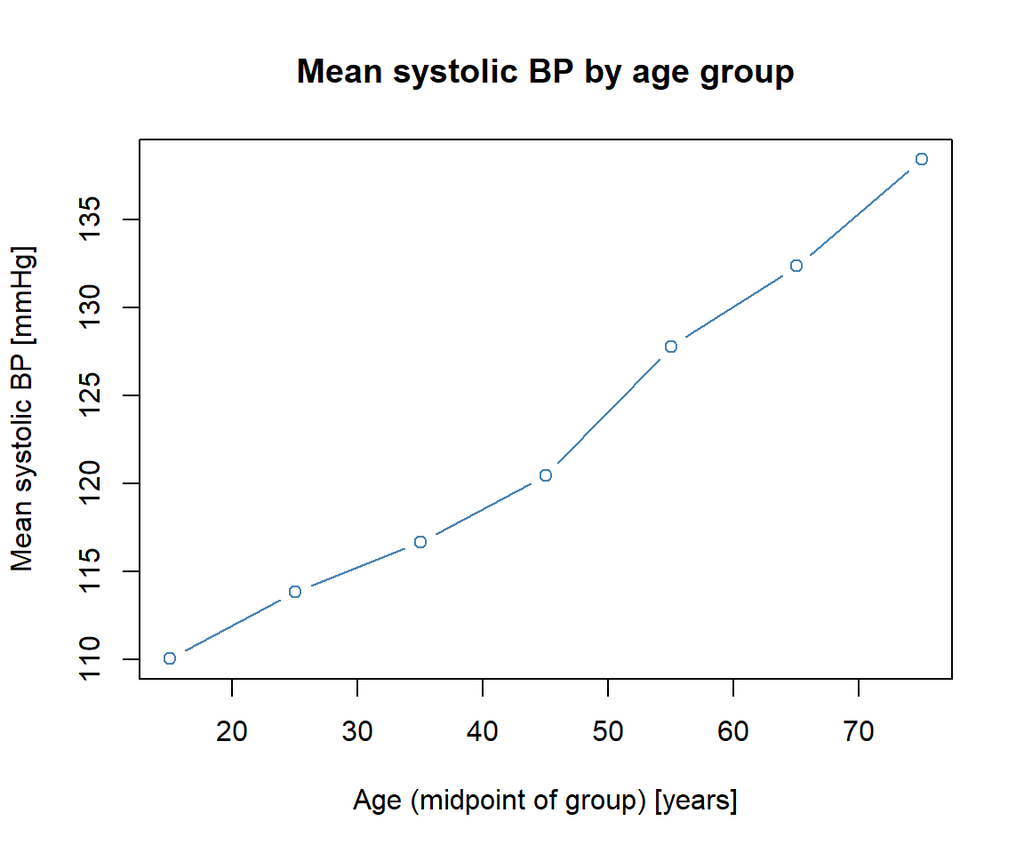

```r
# We define the age groups in which to calculate the mean systolic blood pressure and calculate the mean systolic blood pressure by age group
avg_bp_with_midpoints <- merged_nhanes %>%
  filter(!is.na(BPXSY1), !is.na(RIDAGEYR)) %>%
  mutate(age_group = cut(RIDAGEYR, breaks = seq(10, 80, 10))) %>%
  group_by(age_group) %>%
  summarise(mean_bp = mean(BPXSY1)) %>%
  ungroup() %>%
  mutate(
    # Add midpoints
    age_mid = seq(15, 75, 10)
  )

plot(avg_bp_with_midpoints$age_mid, avg_bp_with_midpoints$mean_bp, type = "b",
     xlab = "Age (midpoint of group) [years]",
     ylab = "Mean systolic BP [mmHg]",
     main = "Mean systolic BP by age group",
     col = "steelblue")
```

💡 The argument `type` is 1-character string giving the type of plot desired. The following values are possible:

- “p” for *points*
- “l” for *lines*
- “b” for *both points and lines*
- “c” for empty points joined by lines
- “o” for overplotted points and lines
- “s” and “S” for stair steps and “h” for histogram-like vertical lines

## 1.6 Pie charts

```r
(gender_table <- table(merged_nhanes$RIAGENDR))
```

```
##
## Female   Male
##   3298   3251
```

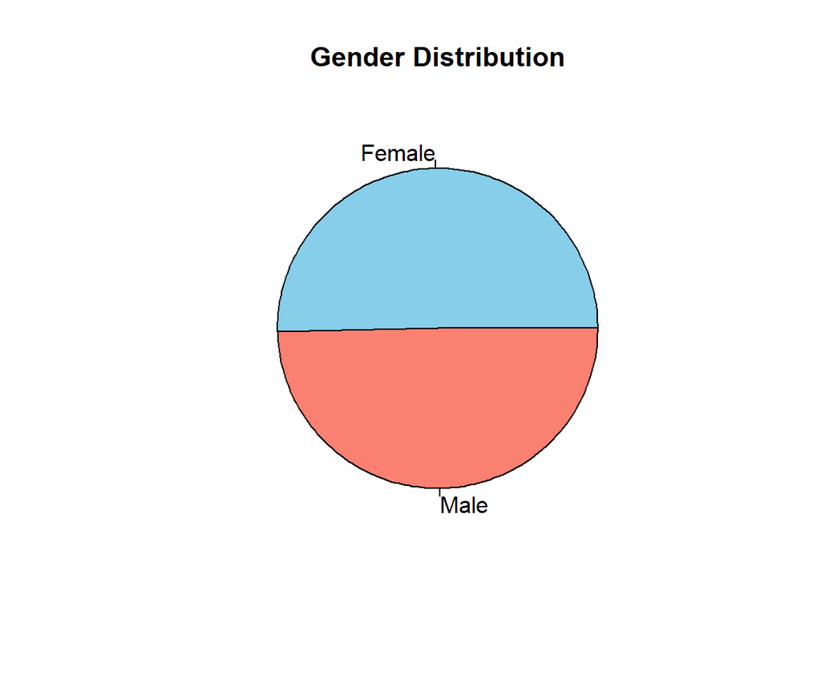

```r
pie(x = gender_table,
    labels = c("Female", "Male"),
    col = c("skyblue", "salmon"),
    main = "Gender Distribution")
```

💡 `table()` uses cross-classifying factors to build a contingency table of the counts at each combination of factor levels.

Personally, I would recommend *avoiding* pie charts, as the human eye is not very good at recognising angle ratios. I favour bar plots, for example.

## 1.7 Mosaic plots

```r
# We first create a table of the data we want to plot in the mosaic plot
(smoking_gender_table <- table(merged_nhanes$SMQ020, merged_nhanes$RIAGENDR))
```

```
##
##              Female Male
##   Don't know      2    1
##   No           1817 1220
##   Refused         0    1
##   Yes           879 1398
```

```r
# We select only the "Yes" and "No" rows
(smoke_table <- smoking_gender_table[c("Yes", "No") ,])
```

```
##
##       Female Male
##   Yes    879 1398
##   No    1817 1220
```

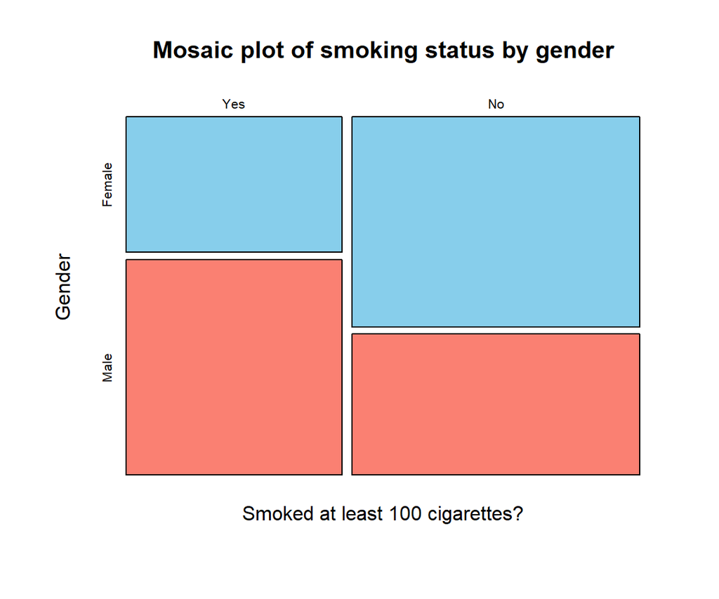

```r
# Mosaic plot
mosaicplot(smoke_table,
           main = "Mosaic plot of smoking status by gender",
           xlab = "Smoked at least 100 cigarettes?",
           ylab = "Gender",
           col = c("skyblue", "salmon"))
```

## 1.8 Forest plots

Base R does not include a built-in function for forest plots, but you can use a package like `forestplot` for that, or `ggplot2` (see below).

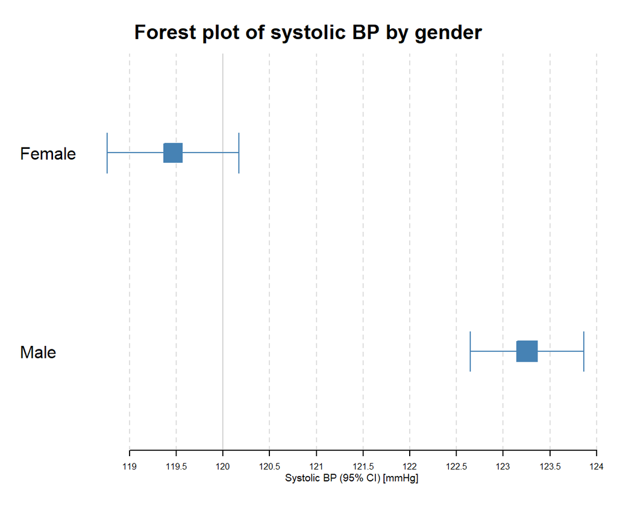

```r
library(forestplot)

# We calculate summary statistics by gender
summary_stats <- merged_nhanes %>%
  filter(!is.na(BPXSY1)) %>% # We remove NAs for BPXSY1
  group_by(RIAGENDR) %>%
  summarise(
    mean = mean(BPXSY1),
    sd = sd(BPXSY1),
    n = n(),
    lower = mean - 1.96 * sd / sqrt(n),
    upper = mean + 1.96 * sd / sqrt(n)
  ) %>%
  ungroup()

# Create the forest plot
forestplot(labeltext = c("Female","Male"),
           mean = summary_stats$mean,
           lower = summary_stats$lower,
           upper = summary_stats$upper,
           zero = 120,
           grid = TRUE,
           ci.vertices = TRUE,
           xlab = "Systolic BP (95% CI) [mmHg]",
           col = fpColors(box = "steelblue",
                          line = "steelblue"),
           title = "Forest plot of systolic BP by gender")
```

## 1.9 Heatmaps

As a reminder: `RIDAGEYR` is the participant’s age (in years), `DMDHHSIZ` is the total number of people in the household, `BMXWT` is the weight (in kg), `BMXHT` is the standing height (in cm), and `BPXSY1` is the systolic blood pressure (first reading, in mmHg).

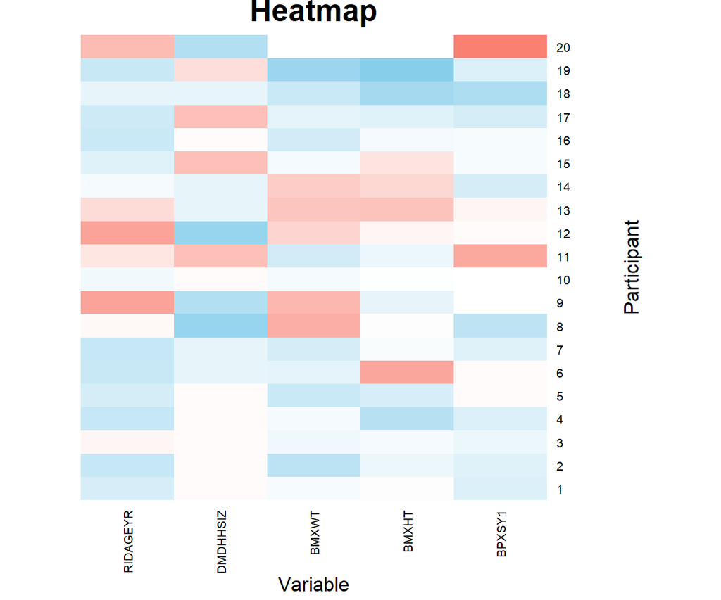

```r
# Let us draw a heat map of different variables for the first 20 participants in
# the data set
heatmap_data <- merged_nhanes %>%
  slice(1:20) %>%
  select(RIDAGEYR, DMDHHSIZ, BMXWT, BMXHT, BPXSY1)
heatmap_data <- as.matrix(heatmap_data)

# Create the heat map
heatmap(x = heatmap_data,
        Colv = NA, Rowv = NA,
        scale = "column", # We standardize by column (by variable)
        col = colorRampPalette(c("skyblue", "white", "salmon"))(100),
        xlab="Variable", ylab="Participant", main="Heatmap",
        cexRow=0.7, cexCol=0.7)
```

## 1.10 Alluvial plots

To draw alluvial plots, please see `ggplot2`, there is no possibility to draw such plots using base R.

## 1.11 Kaplan-Meier curves

Base R requires the `survival` package in order to draw Kaplan-Meier survival curves.

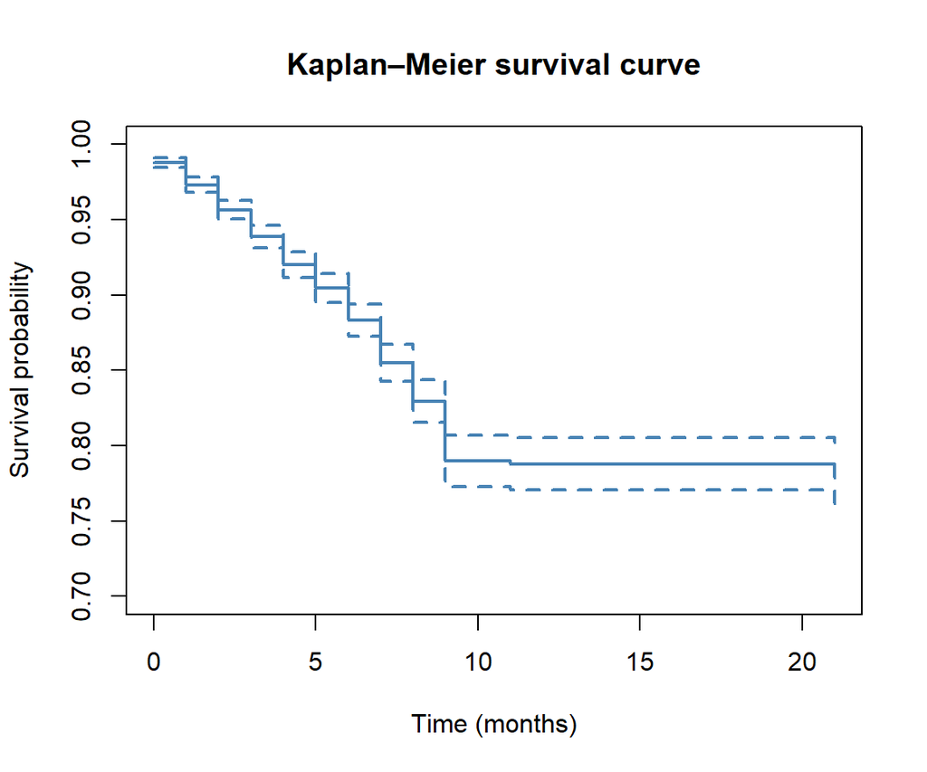

```r
library(survival)

# Filter out data outside of window (> 24 months)
merged_nhanes_no_outliers <- merged_nhanes_with_mort[merged_nhanes_with_mort$PERMTH_INT <= 24, ]

# Fit Kaplan–Meier survival curves
fit <- survfit(Surv(PERMTH_INT, MORTSTAT) ~ 1,
               data = merged_nhanes_no_outliers)

# Plot in base R
plot(fit,
     col = "steelblue",
     lwd = 2,
     xlab = "Time (months)",
     ylab = "Survival probability",
       ylim = c(0.7,1),
     main = "Kaplan–Meier survival curve")
```

## 1.12 Exercises

### 1.12.1 Exercise 1

✏️ Exercise 1: Create box plots of the first, second and third systolic blood pressure readings by gender (i.e. each of the three plots should contain two box plots: one for males and one for females) using base R. Display all three plots (1st, 2nd and 3rd readings) in the same output panel.

💡 *Hint:* Try using the `par()` function (e.g. `par(mfrow=c(2,3))` to display multiple plots in the same panel; do not forget to reset it to `par(mfrow=c(1,1))` afterwards!)

### 1.12.2 Exercise 2

✏️ Exercise 2: Create a histogram showing the systolic blood pressure (1st reading) for each smoking status category (`"Not at all", "Some days", "Every day"`, excluding those who refused to provide their smoking status) using base R. Set the number of breaks to 20. You should get three different plots. Display them all in the same output panel.

# 2 Including plots using `ggplot2`

```r
# Start by installing ggplot2
install.packages("ggplot2")
library(ggplot2) # after installation

# Note that the ggplot2 package is included in some R package collections, e.g. the tidyverse collection
install.packages("tidyverse")
library(tidyverse) # after installation
```

`ggplot2` is based on the grammar of graphics: the idea that every graph can be built from the same basic components:

- a *data set*,
- a *coordinate system*, and
- *geoms*: visual marks (like points, lines, bars) that represent data.

Structure of a `ggplot2` graph:

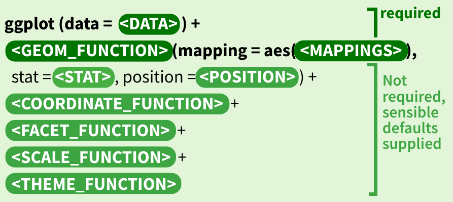

How to build a plot:

1. Start with `ggplot()`, where you provide the dataset (and optionally the aesthetic mapping).
2. Add layers, such as:
- `geom_point()` (scatter plot)
- `geom_histogram()` (histogram)
- `geom_line()` (line plot)
- `scales` (e.g., scale_y_log10())
- `faceting` (e.g., facet_wrap())
- `coordinate systems` (e.g., coord_flip())
3. Define aesthetics using `aes()`: these describe how variables in the data are mapped to visual properties like: x, y, color, fill, linetype, size, etc.

💡 You can place `aes()` either in `ggplot()` (to apply it *globally*) or inside the individual `geom_*()` functions (to apply it *locally*).

The geom function must be chosen according to the type of data examined (two continuous variables, one categorical and one continuous variable, etc.).

## 2.1 Scatter plots

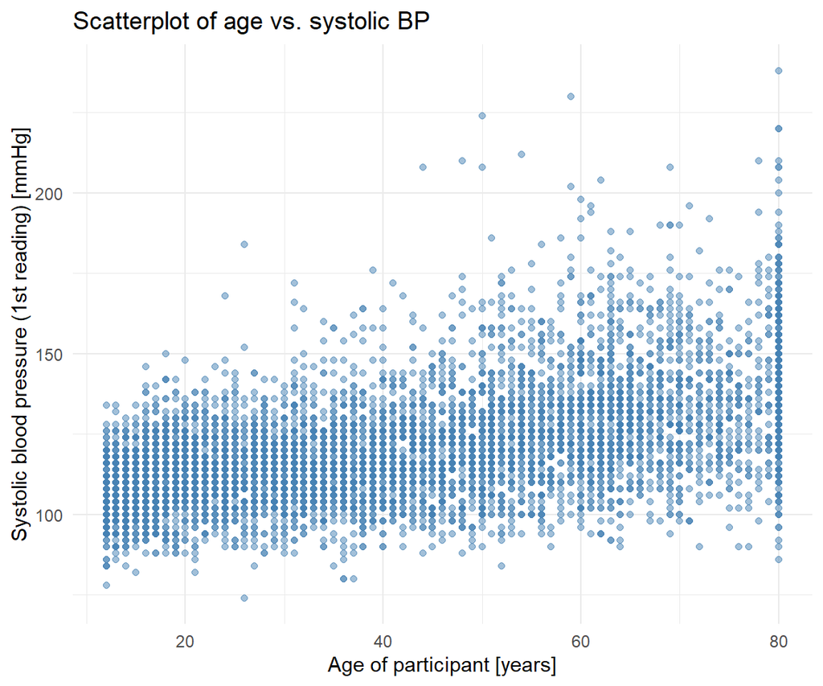

```r
ggplot(merged_nhanes, aes(x = RIDAGEYR, y = BPXSY1)) +
  geom_point(alpha = 0.5, col = "steelblue") +
  labs(title = "Scatterplot of age vs. systolic BP",
       x = "Age of participant [years]",
       y = "Systolic blood pressure (1st reading) [mmHg]") +
  theme_minimal()
```

Or equivalently:

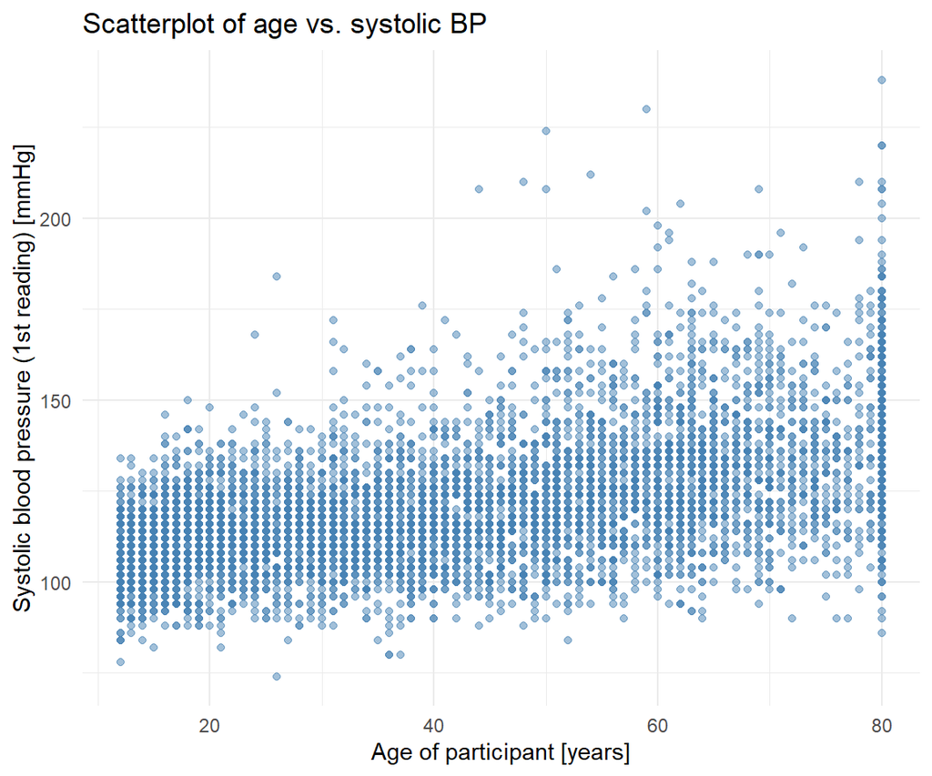

```r
ggplot(merged_nhanes) +
  geom_point(aes(x = RIDAGEYR, y = BPXSY1), alpha = 0.5, col = "steelblue") +
  labs(title = "Scatterplot of age vs. systolic BP",
       x = "Age of participant [years]",
       y = "Systolic blood pressure (1st reading) [mmHg]") +
  theme_minimal()
```

## 2.2 Box plots

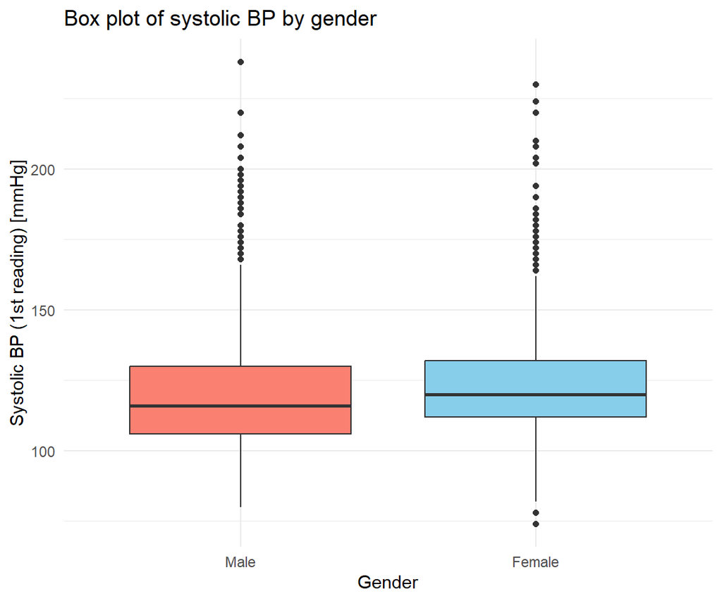

```r
ggplot(data = merged_nhanes, aes(x = factor(RIAGENDR, labels = c("Male", "Female")),
                                 y = BPXSY1,
                                 fill = factor(RIAGENDR))) +
  geom_boxplot() +
  scale_fill_manual(values = c("salmon", "skyblue")) +
  labs(title = "Box plot of systolic BP by gender",
       x = "Gender",
       y = "Systolic BP (1st reading) [mmHg]") +
  theme_minimal() +
  theme(legend.position = "none")
```

## 2.3 Bar plots

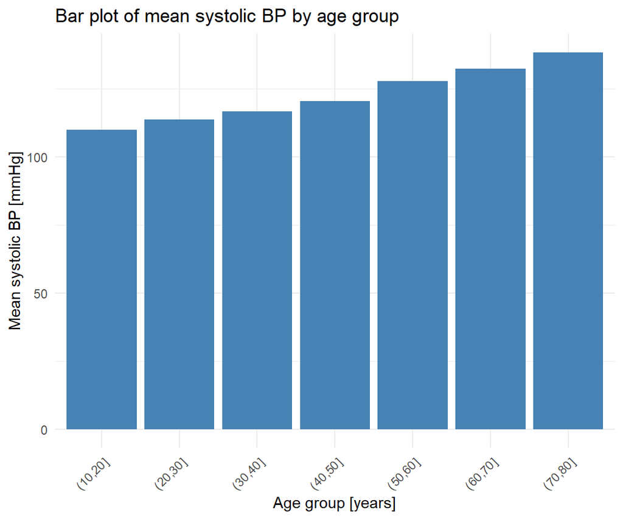

```r
ggplot(avg_bp, aes(x = age_group, y = mean_bp)) +
  geom_bar(stat = "identity", fill = "steelblue") +
  labs(title = "Bar plot of mean systolic BP by age group",
       x = "Age group [years]",
       y = "Mean systolic BP [mmHg]") +
  theme_minimal() +
  theme(axis.text.x = element_text(angle = 45, hjust = 1))
```

## 2.4 Histograms

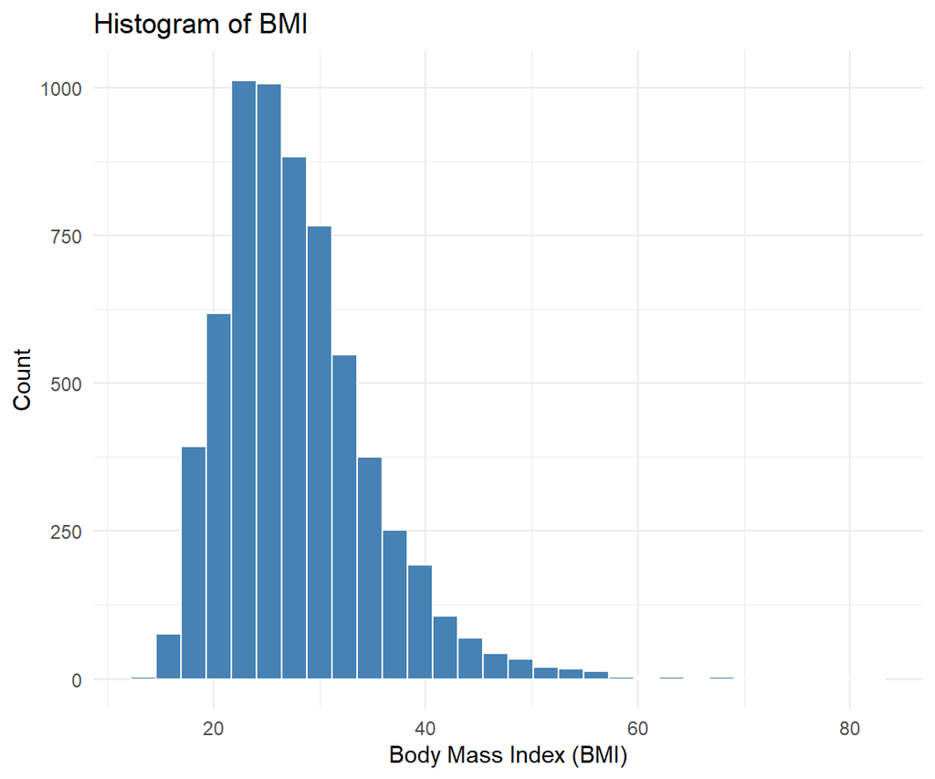

```r
ggplot(merged_nhanes, aes(x = BMXBMI)) +
  geom_histogram(bins = 30, fill = "steelblue", color = "white") +
  labs(title = "Histogram of BMI",
       x = "Body Mass Index (BMI)",
       y = "Count") +
  theme_minimal()
```

💡 A quick reminder that the number of bins in a histogram is extremely important and should be given careful consideration, as the appearance of the data can vary significantly depending on this choice, which could potentially be misleading.

An example with the age of the household reference person:

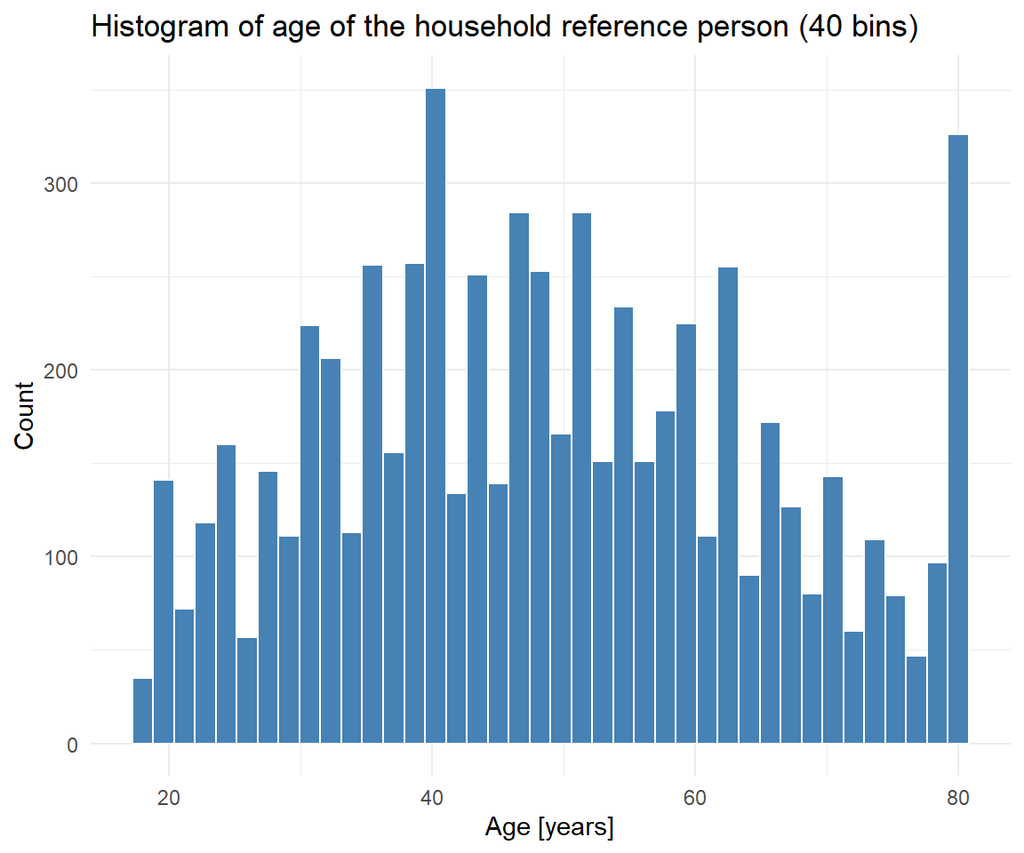

```r
ggplot(merged_nhanes, aes(x = DMDHRAGE)) +
  geom_histogram(bins = 40, fill = "steelblue", color = "white") +
  labs(title = "Histogram of age of the household reference person (40 bins)",
       x = "Age [years]",
       y = "Count") +
  theme_minimal()
```

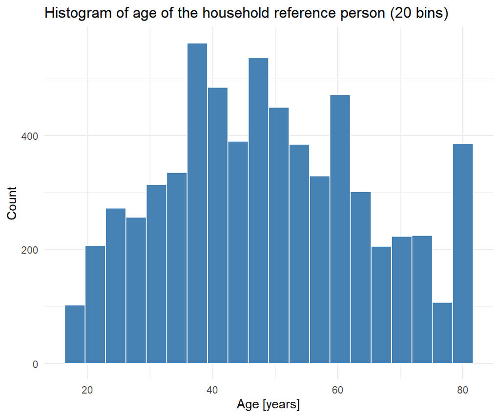

```r
ggplot(merged_nhanes, aes(x = DMDHRAGE)) +
  geom_histogram(bins = 20, fill = "steelblue", color = "white") +
  labs(title = "Histogram of age of the household reference person (20 bins)",
       x = "Age [years]",
       y = "Count") +
  theme_minimal()
```

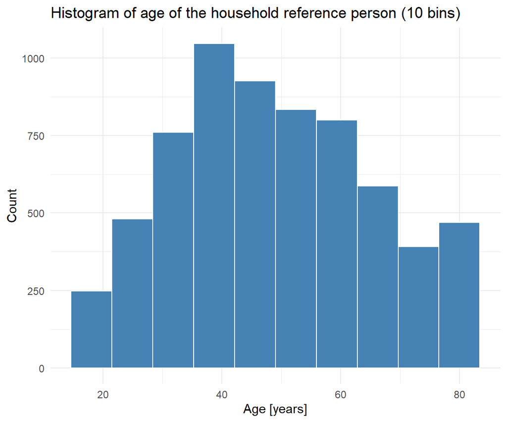

```r
ggplot(merged_nhanes, aes(x = DMDHRAGE)) +
  geom_histogram(bins = 10, fill = "steelblue", color = "white") +
  labs(title = "Histogram of age of the household reference person (10 bins)",
       x = "Age [years]",
       y = "Count") +
  theme_minimal()
```

## 2.5 Line plots

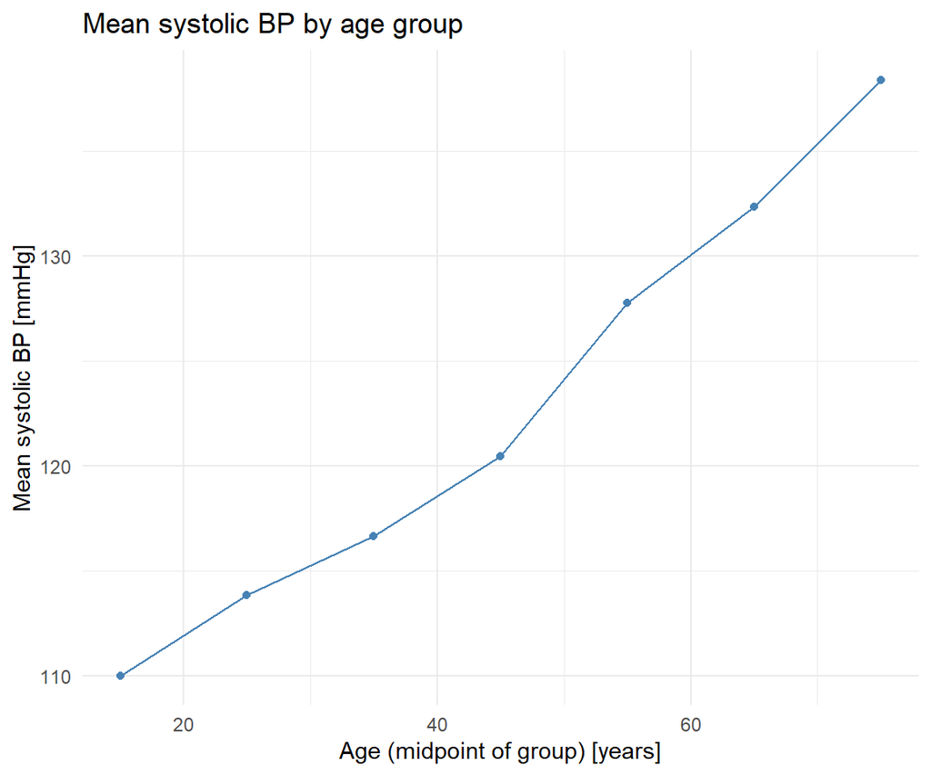

```r
ggplot(avg_bp_with_midpoints, aes(x = age_mid, y = mean_bp)) +
  geom_line(col = "steelblue") +
  geom_point(col = "steelblue") +
  labs(title = "Mean systolic BP by age group",
       x = "Age (midpoint of group) [years]",
       y = "Mean systolic BP [mmHg]") +
  theme_minimal()
```

## 2.6 Pie charts

[figure not shown]

```r
# Count proportions for each gender
gender_counts <- merged_nhanes %>%
  filter(!is.na(RIAGENDR)) %>%                     # Remove NAs if any
  count(Gender = RIAGENDR) %>%                      # Count by gender, rename column to 'Gender'
  mutate(
    prop = n / sum(n),                              # Compute proportion
    ypos = cumsum(prop) - 0.5 * prop                # Compute y position for label
  )

ggplot(gender_counts, aes(x = "", y = prop, fill = Gender)) +
  geom_col(width = 1) +
  coord_polar(theta = "y") +
  geom_text(aes(y = ypos, label = scales::percent(prop)), color = "white") +
  scale_fill_manual(values = c("salmon", "skyblue")) +
  labs(title = "Pie chart of gender distribution") +
  theme_void()
```

## 2.7 Mosaic plots

`ggplot2` does not include a built-in function for mosaic plots, but can be extended with the `ggmoisaic` package for that.

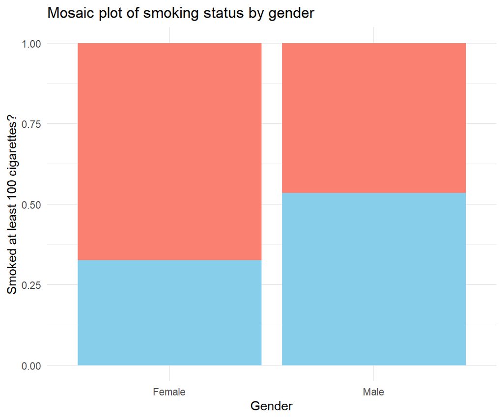

```r
library(ggmosaic)

mosaic <- merged_nhanes[merged_nhanes$SMQ020 %in% c("Yes", "No"), c("RIAGENDR", "SMQ020")]

# Convert the relevant columns to factors
mosaic$RIAGENDR <- factor(mosaic$RIAGENDR)       # Gender
mosaic$SMQ020 <- factor(mosaic$SMQ020, levels = c("No", "Yes"))  # Smoking

ggplot(mosaic, aes(x = RIAGENDR, fill = SMQ020)) +
  geom_bar(position = "fill") +
  scale_fill_manual(values = c("salmon", "skyblue")) +
  labs(x = "Gender", y = "Smoked at least 100 cigarettes?",
       title = "Mosaic plot of smoking status by gender") +
  theme_minimal() +
  theme(legend.position = "none")
```

## 2.8 Forest plots

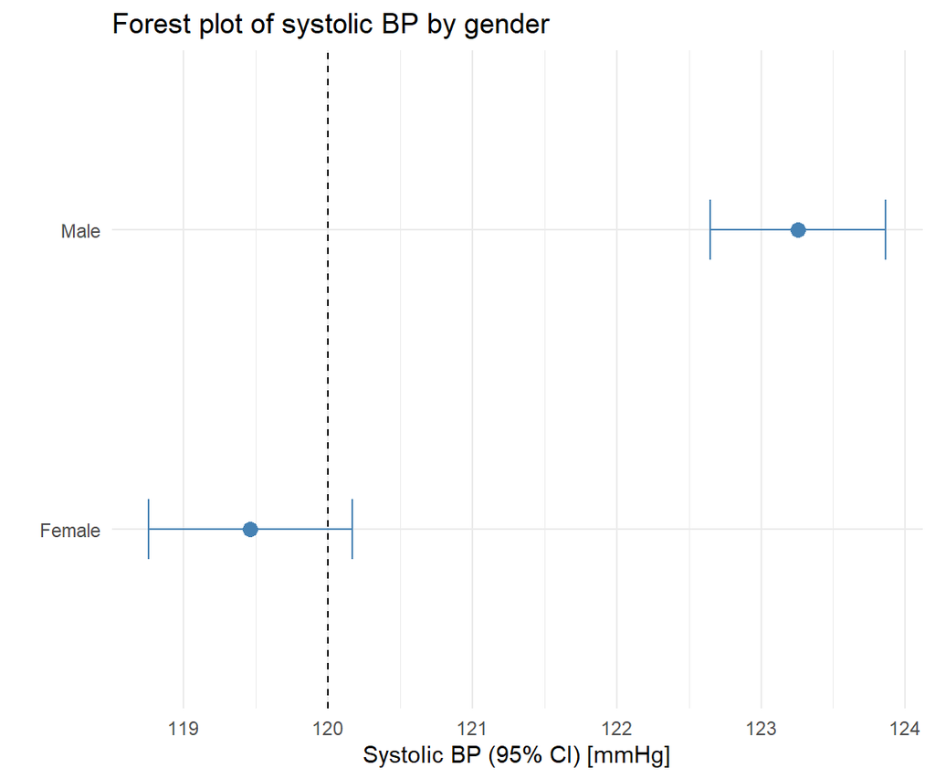

```r
# Calculate summary statistics by gender
forest_df <- merged_nhanes %>%
  filter(!is.na(BPXSY1), !is.na(RIAGENDR)) %>%
  group_by(Gender = RIAGENDR) %>%
  summarise(
    mean = mean(BPXSY1),
    sd = sd(BPXSY1),
    n = n(),
    lower = mean - 1.96 * sd / sqrt(n),
    upper = mean + 1.96 * sd / sqrt(n),
    .groups = "drop"
  )

ggplot(forest_df, aes(x = mean, y = Gender)) +
  geom_point(size = 3, color = "steelblue") +
  geom_errorbarh(aes(xmin = lower, xmax = upper), height = 0.2, color = "steelblue") +
  geom_vline(xintercept = 120, linetype = "dashed") +
  labs(title = "Forest plot of systolic BP by gender",
       x = "Systolic BP (95% CI) [mmHg]",
       y = "") +
  theme_minimal()
```

## 2.9 Heatmaps

As a reminder: `RIDAGEYR` is the participant’s age (in years), `DMDHHSIZ` is the total number of people in the household, `BMXWT` is the weight (in kg), `BMXHT` is the standing height (in cm), and `BPXSY1` is the systolic blood pressure (first reading, in mmHg).

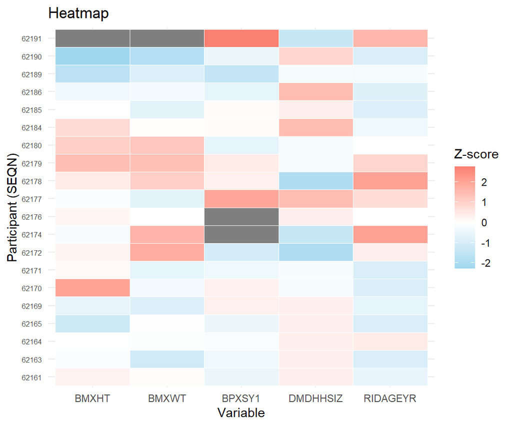

```r
# Let us draw a heat map of different variables for the first 20 participants in
# the data set
heatmap_data <- merged_nhanes %>%
  slice(1:20) %>%
  select(SEQN, RIDAGEYR, DMDHHSIZ, BMXWT, BMXHT, BPXSY1)

# We reshape to long format and standardize
heatmap_scaled <- heatmap_data %>%
  mutate(across(-SEQN, scale)) %>%
  pivot_longer(-SEQN, names_to = "Variable", values_to = "Value")

# Create the heat map
ggplot(heatmap_scaled, aes(x = Variable, y = factor(SEQN), fill = Value)) +
  geom_tile(color = "white") +
  scale_fill_gradient2(low = "skyblue", mid = "white", high = "salmon") +
  labs(x = "Variable", y = "Participant (SEQN)", fill = "Z-score",
       title = "Heatmap") +
  theme_minimal() +
  theme(axis.text.y = element_text(size = 6))
```

💡 `pivot_longer(data, cols, ...)` “lengthens” data, increasing the number of rows and decreasing the number of columns. It’s especially useful for plotting functions like `geom_tile()` or `geom_flow()` that require data in a long format. Essentially, it takes the values from the specified columns (`cols`) and stacks them into a single column (`values_to`), with an additional column indicating the original column name (`names_to`).

## 2.10 Alluvial plots

Alluvial plots require the use of the package `ggalluvial` in addition to `ggplot2`.

```r
library(ggalluvial)

# We will draw an alluvial plot of the three systolic blood pressure readings of the first 50 participants with no NA values in the corresponding columns
bp_data <- merged_nhanes %>%
  filter(!is.na(BPXSY1),
         !is.na(BPXSY2),
         !is.na(BPXSY3)) %>%
  slice(1:50) %>%
  select(SEQN, BPXSY1, BPXSY2, BPXSY3)

# We put the BP reading into three groups
bp_data <- bp_data %>%
  mutate(BPXSY1 = cut(BPXSY1,
                      breaks = c(0, 120, 130, 200),
                      labels = c("[0-120)", "[120-130)", "[130-200)"),
                      right = FALSE)) %>%
  mutate(BPXSY2 = cut(BPXSY2,
                      breaks = c(0, 120, 130, 200),
                      labels = c("[0-120)", "[120-130)", "[130-200)"),
                      right = FALSE)) %>%
  mutate(BPXSY3 = cut(BPXSY3,
                      breaks = c(0, 120, 130, 200),
                      labels = c("[0-120)", "[120-130)", "[130-200)"),
                      right = FALSE))

# We reshape to long format for ggalluvial
bp_long <- bp_data %>%
  pivot_longer(cols = starts_with("BPXSY"),
               names_to = "Reading",
               values_to = "Systolic_BP")

# This is how our data looks like before plotting
bp_long
```

| SEQN | Reading | Systolic_BP |
| --- | --- | --- |
| 62161 | BPXSY1 | [0-120) |
| 62161 | BPXSY2 | [0-120) |
| 62161 | BPXSY3 | [0-120) |
| 62163 | BPXSY1 | [0-120) |
| 62163 | BPXSY2 | [0-120) |
| 62163 | BPXSY3 | [0-120) |
| 62164 | BPXSY1 | [0-120) |
| 62164 | BPXSY2 | [0-120) |
| 62164 | BPXSY3 | [120-130) |
| 62165 | BPXSY1 | [0-120) |

[output cut: 140 more lines]

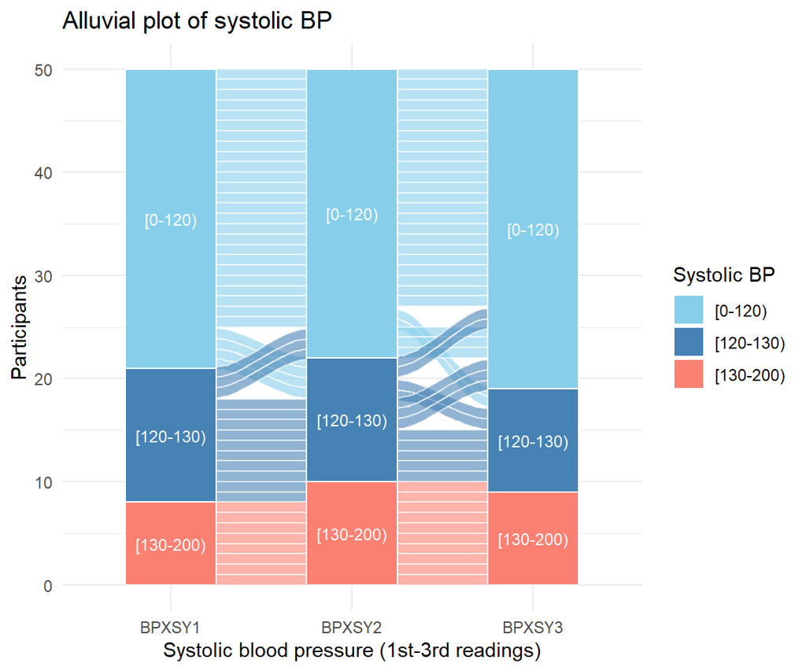

```r
# Alluvial plot
ggplot(bp_long,
       aes(x = Reading,
           stratum = Systolic_BP,
           alluvium = SEQN,
           fill = Systolic_BP,
           label = Systolic_BP)) +
  geom_flow(stat = "alluvium", lode.guidance = "forward", alpha = 0.6, color = "white") +
  geom_stratum(width = 0.5, color = "white") +
  geom_text(stat = "stratum", size = 3, color = "white") +
  scale_fill_manual(values = c("skyblue", "steelblue", "salmon")) +
  theme_minimal() +
  labs(title = "Alluvial plot of systolic BP",
       x = "Systolic blood pressure (1st-3rd readings)",
       y = "Participants",
       fill = "Systolic BP")
```

## 2.11 Kaplan-Meier curves

`ggplot2` does not include a built-in function for KM curves, but can be extended with the `survminer` package for that.

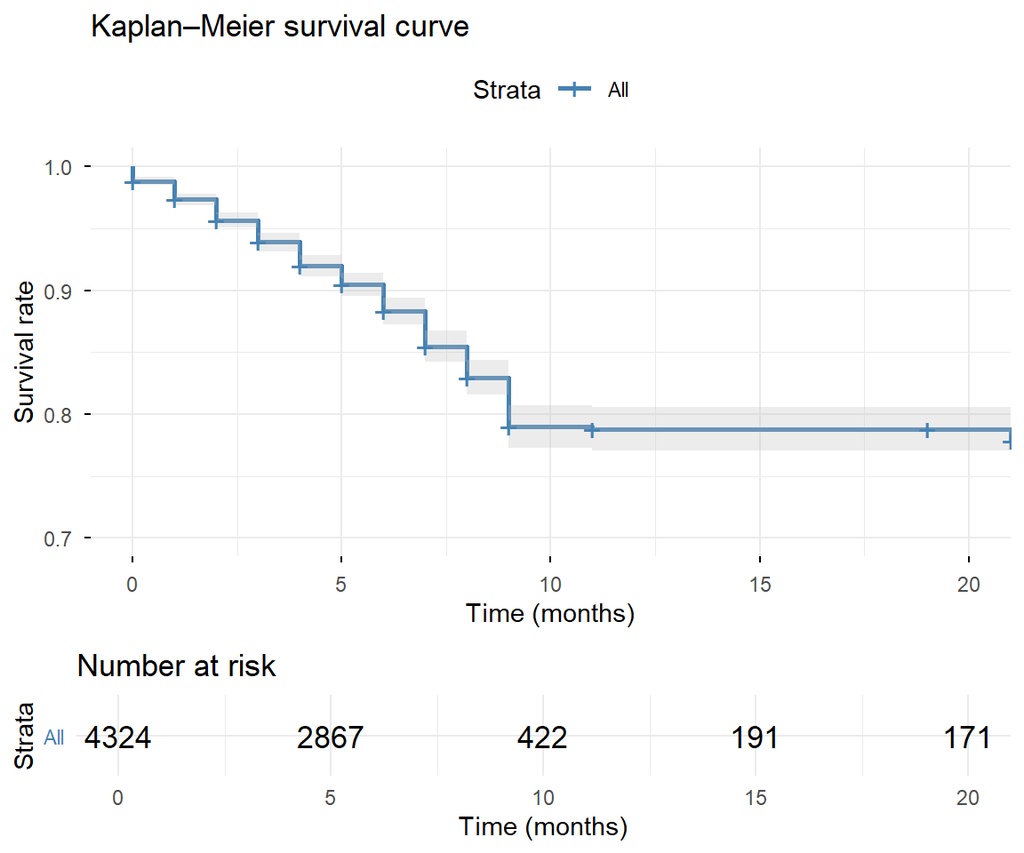

```r
library(survminer)

# Fit Kaplan–Meier survival curves (already done)
fit <- survfit(Surv(PERMTH_INT, MORTSTAT) ~ 1,
               data = merged_nhanes_no_outliers)

# Plot with ggsurvplot
ggsurvplot(fit,
           data = merged_nhanes_no_outliers,
           palette = c("steelblue"),
           conf.int = TRUE,
           xlab = "Time (months)",
           ylab = "Survival rate",
           ylim = c(0.7, 1),
           risk.table = TRUE,
           title = "Kaplan–Meier survival curve",
           ggtheme = theme_minimal())
```

## 2.12 Exercises

### 2.12.1 Exercise 3

✏️ Exercise 3: Using the same age groups as in the examples (`(10,20], (20,30], (30,40], (40,50], (50,60], (60,70], (70,80]`), create a bar plot showing the median BMI by age group using `ggplot2`. Then produce two further bar plots showing the same data for each gender, and display them in the same output panel, using the same y-axis to allow for better comparison.

💡 *Hints:* Try using the `grid.arrange()` function from the `gridExtra` package (e.g. `grid.arrange(plot1, plot2, ncol=2)`), and the argument `ylim` in the `ggplot()` function.

### 2.12.2 Exercise 4

✏️ Exercise 4: Reproduce the alluvial plot showing the evolution of the systolic blood pressure (i.e. with `ggplot2`), but using the diastolic blood pressure (`BPXDI1`, `BPXDI2`, `BPXDI3`). Use only the **last 100** participants with no NAs. Use the following breaks: `c(0, 60, 70, 80, 120)`.

💡 *Hints:* Try using the `slice_tail()` function to select the last 100 participants.

# 3 Saving plots

## 3.1 Base R

We would use the `jpeg()` function to save a plot as a JPEG image and the `png()` function to save it as a PNG image. Please note that after the plotting and saving, we need to call the function `dev.off()` to save the file.

We can specify the resolution we want with arguments width and height. We can also specify the full/relative path of the file we want to save if we don’t want to save it in the current directory.

```r
results_directory <- "C:/GitHub/rforphysicians/docs/plots/"

jpeg(file = paste0(results_directory,"hist_BMI.jpeg"),
     width = 10,
     height = 6,
     units = "in",
     res=100)

hist(merged_nhanes$BMXBMI,
     breaks = 30,
     freq = TRUE,
     col = "steelblue",
     xlab = "Body Mass Index (BMI)",
     main = "Histogram of BMI")

dev.off()

png(file= paste0(results_directory,"pie_chart_gender.png"),
    width = 10,
    height = 6,
    units="in",
    res=100)

pie(x = gender_table,
    labels = c("Female", "Male"),
    col = c("skyblue", "salmon"),
    main = "Gender Distribution")

dev.off()
```

## 3.2 `ggplot2`

Saving plots created using the `ggplot2` package is very easy with the `ggsave()` function. However, the plot must first be stored in a variable; otherwise, the function will simply save the last plot displayed. The function guesses the type of graphics from the file extension.

We can specify the resolution we want with arguments width and height. We can also specify the full/relative path of the file we want to save if we don’t want to save it in the current directory.

```r
boxplot_syst_bp_by_gender <-
  ggplot(data = merged_nhanes,
         aes(x = factor(RIAGENDR, labels = c("Male", "Female")),
             y = BPXSY1,
             fill = factor(RIAGENDR))) +
  geom_boxplot() +
  scale_fill_manual(values = c("salmon", "skyblue")) +
  labs(title = "Box plot of systolic BP by gender",
       x = "Gender",
       y = "Systolic BP (1st reading) [mmHg]") +
  theme_minimal() +
  theme(legend.position = "none")

ggsave(filename = "boxplot_syst_bp_by_gender.png",
  plot = boxplot_syst_bp_by_gender,
  bg = 'white',
  width = 10,
  height = 6,
  units = c("in"),
  path = results_directory)
```

## 3.3 Exercises

Please note that those are only examples, there are always many ways to solve the same task!

### 3.3.1 Exercise 5

✏️ Exercise 5: Save the three box plots from exercise 1 as one JPEG image using `jpeg()`.

### 3.3.2 Exercise 6

✏️ Exercise 6: Save the two bar plots from exercise 3 as one PNG image using `ggsave()`.

# 4 Solutions to the exercises

## 4.1 Exercise 1

☑️ Exercise 1:

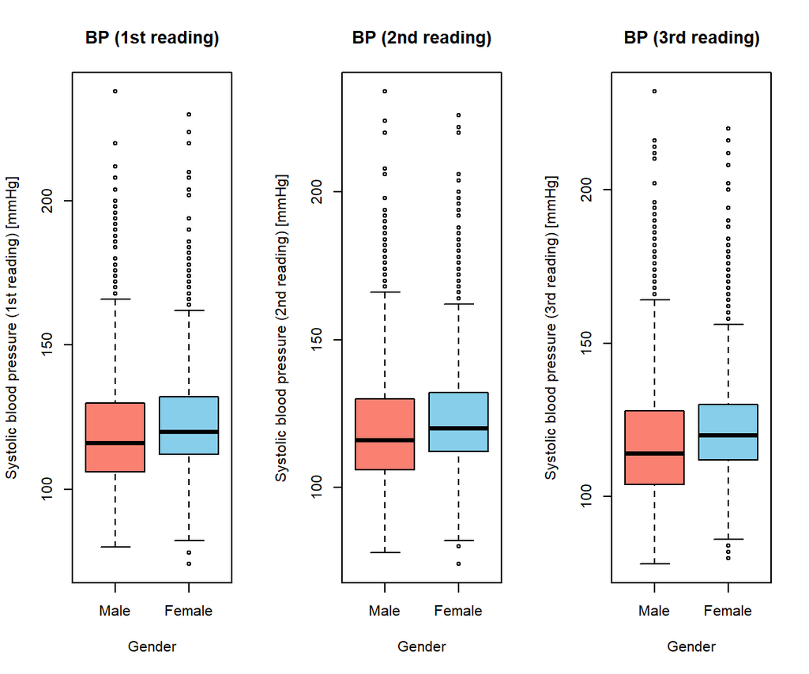

```r
par(mfrow=c(1,3))
boxplot(merged_nhanes$BPXSY1 ~ merged_nhanes$RIAGENDR,
        names = c("Male", "Female"),
        xlab = "Gender",
        ylab = "Systolic blood pressure (1st reading) [mmHg]",
        main = "BP (1st reading)",
        col = c("salmon", "skyblue"))
boxplot(merged_nhanes$BPXSY2 ~ merged_nhanes$RIAGENDR,
        names = c("Male", "Female"),
        xlab = "Gender",
        ylab = "Systolic blood pressure (2nd reading) [mmHg]",
        main = "BP (2nd reading)",
        col = c("salmon", "skyblue"))
boxplot(merged_nhanes$BPXSY3 ~ merged_nhanes$RIAGENDR,
        names = c("Male", "Female"),
        xlab = "Gender",
        ylab = "Systolic blood pressure (3rd reading) [mmHg]",
        main = "BP (3rd reading)",
        col = c("salmon", "skyblue"))
```

```r
par(mfrow=c(1,1))
```

## 4.2 Exercise 2

☑️ Exercise 2:

```r
# We identify the different smoking status
table(merged_nhanes$SMQ040)
```

```
##
##  Every day Not at all    Refused  Some days
##        878       1210          2        187
```

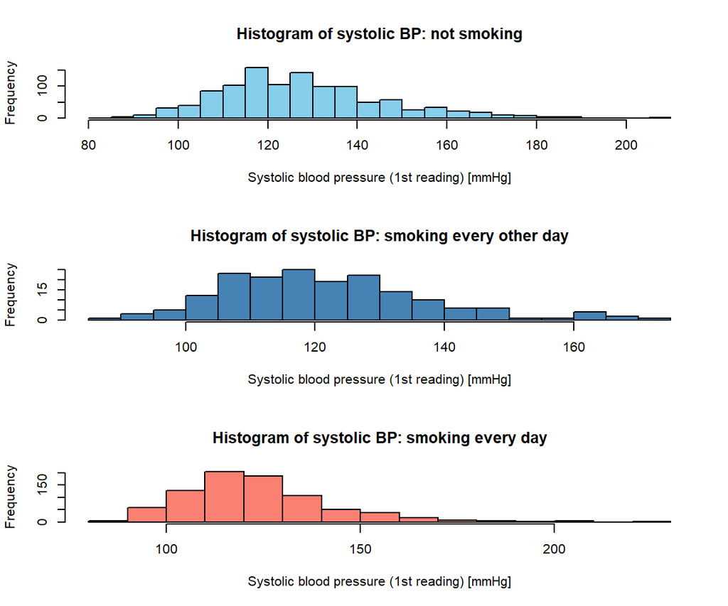

```r
par(mfrow=c(3,1))
hist(merged_nhanes[merged_nhanes$SMQ040=="Not at all",]$BPXSY1,
     breaks = 20,
     freq = TRUE,
     col = "skyblue",
     xlab = "Systolic blood pressure (1st reading) [mmHg]",
     main = "Histogram of systolic BP: not smoking")
hist(merged_nhanes[merged_nhanes$SMQ040=="Some days",]$BPXSY1,
     breaks = 20,
     freq = TRUE,
     col = "steelblue",
     xlab = "Systolic blood pressure (1st reading) [mmHg]",
     main = "Histogram of systolic BP: smoking every other day")
hist(merged_nhanes[merged_nhanes$SMQ040=="Every day",]$BPXSY1,
     breaks = 20,
     freq = TRUE,
     col = "salmon",
     xlab = "Systolic blood pressure (1st reading) [mmHg]",
     main = "Histogram of systolic BP: smoking every day")
```

```r
par(mfrow=c(1,1))

# In case you were wondering why the BP is higher in the group of non-smokers
merged_nhanes$age_group <- cut(merged_nhanes$RIDAGEYR, breaks = seq(10, 80, 10))
table(merged_nhanes[merged_nhanes$SMQ040!="Refused",]$SMQ040, merged_nhanes[merged_nhanes$SMQ040!="Refused",]$age_group)
```

```
##
##              (10,20] (20,30] (30,40] (40,50] (50,60] (60,70] (70,80]
##   Every day       16     165     187     179     172     111      48
##   Not at all       3      84     152     148     228     283     312
##   Some days        5      60      35      30      26      24       7
```

## 4.3 Exercise 3

☑️ Exercise 3:

```r
# We define the age groups
age_groups <- cut(x = merged_nhanes$RIDAGEYR, breaks = seq(10, 80, 10))
head(age_groups)
```

```
## [1] (20,30] (10,20] (40,50] (10,20] (20,30] (10,20]
## Levels: (10,20] (20,30] (30,40] (40,50] (50,60] (60,70] (70,80]
```

```r
# We calculate the median BMI by age group
(med_bmi <- aggregate(BMXBMI ~ age_groups, data = merged_nhanes, FUN = function(x) median(x, na.rm = TRUE)))
```

| age_groups | BMXBMI |
| --- | --- |
| (10,20] | 22.60 |
| (20,30] | 25.80 |
| (30,40] | 27.45 |
| (40,50] | 28.60 |
| (50,60] | 28.50 |
| (60,70] | 28.15 |
| (70,80] | 27.05 |

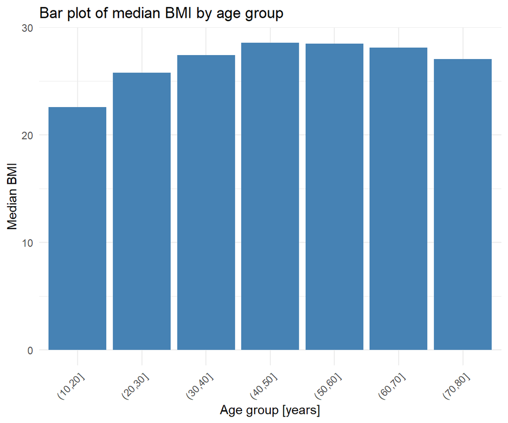

```r
ggplot(med_bmi, aes(x = age_groups, y = BMXBMI)) +
  geom_bar(stat = "identity", fill = "steelblue") +
  labs(title = "Bar plot of median BMI by age group",
       x = "Age group [years]",
       y = "Median BMI") +
  theme_minimal() +
  theme(axis.text.x = element_text(angle = 45, hjust = 1))
```

```r
# We calculate the median BMI by age group and by gender
(med_bmi <- aggregate(BMXBMI ~ age_groups + RIAGENDR, data = merged_nhanes, FUN = function(x) median(x, na.rm = TRUE)))
```

| age_groups | RIAGENDR | BMXBMI |
| --- | --- | --- |
| (10,20] | Female | 22.50 |
| (20,30] | Female | 25.75 |
| (30,40] | Female | 27.40 |
| (40,50] | Female | 28.90 |
| (50,60] | Female | 28.95 |
| (60,70] | Female | 29.90 |
| (70,80] | Female | 27.00 |
| (10,20] | Male | 22.70 |
| (20,30] | Male | 25.80 |
| (30,40] | Male | 27.50 |

[output cut: 4 more lines]

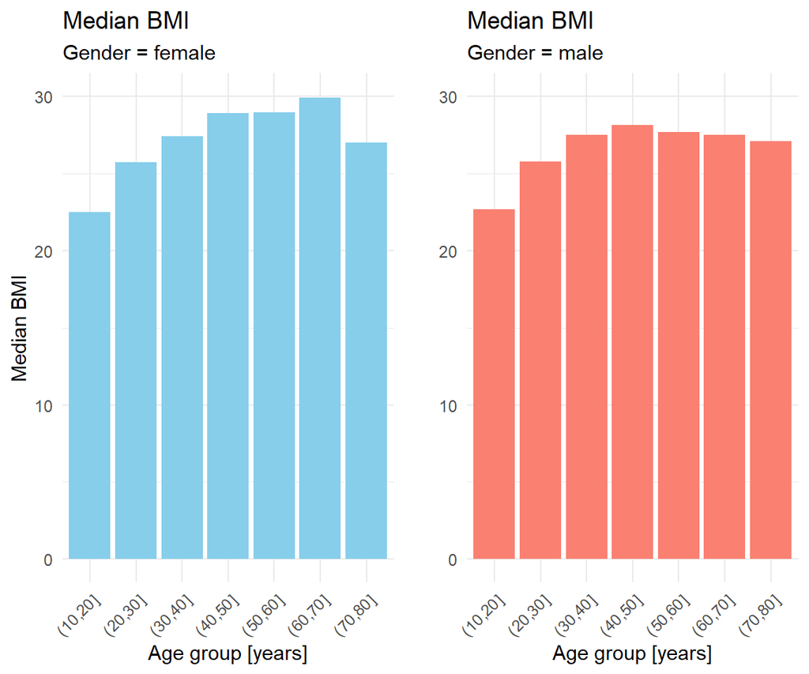

```r
med_bmi_fem <- med_bmi[med_bmi$RIAGENDR == "Female",]
med_bmi_male <- med_bmi[med_bmi$RIAGENDR == "Male",]

plot1 <- ggplot(med_bmi_fem, aes(x = age_groups, y = BMXBMI)) +
  geom_bar(stat = "identity", fill = "skyblue") +
  labs(title = "Median BMI",
       subtitle = "Gender = female",
       x = "Age group [years]",
       y = "Median BMI") +
  theme_minimal() +
  ylim(c(0,30)) +
  theme(axis.text.x = element_text(angle = 45, hjust = 1))
plot2 <- ggplot(med_bmi_male, aes(x = age_groups, y = BMXBMI)) +
  geom_bar(stat = "identity", fill = "salmon") +
  labs(title = "Median BMI",
       subtitle = "Gender = male",
       x = "Age group [years]",
       y = "") +
  theme_minimal() +
  ylim(c(0,30)) +
  theme(axis.text.x = element_text(angle = 45, hjust = 1))

library(gridExtra)
grid.arrange(plot1, plot2, ncol=2)
```

## 4.4 Exercice 4

☑️ Exercise 4:

```r
library(ggalluvial)

# We will draw an alluvial plot of the three diastolic blood pressure readings of the last 100 participants with no NA values in the corresponding columns
bp_data <- merged_nhanes %>%
  filter(!is.na(BPXDI1),
         !is.na(BPXDI2),
         !is.na(BPXDI3)) %>%
  slice_tail(n = 100) %>%
  select(SEQN, BPXDI1, BPXDI2, BPXDI3)

# We put the BP reading into four groups
bp_data <- bp_data %>%
  mutate(BPXDI1 = cut(BPXDI1,
                      breaks = c(0, 60, 70, 80, 120),
                      labels = c("[0-60)", "[60-70)", "[70-80)", "[80-120)"),
                      right = FALSE)) %>%
  mutate(BPXDI2 = cut(BPXDI2,
                      breaks = c(0, 60, 70, 80, 120),
                      labels = c("[0-60)", "[60-70)", "[70-80)", "[80-120)"),
                      right = FALSE)) %>%
  mutate(BPXDI3 = cut(BPXDI3,
                      breaks = c(0, 60, 70, 80, 120),
                      labels = c("[0-60)", "[60-70)", "[70-80)", "[80-120)"),
                      right = FALSE))

# We reshape to long format for ggalluvial
bp_long <- bp_data %>%
  pivot_longer(cols = starts_with("BPXDI"),
               names_to = "Reading",
               values_to = "Diastolic_BP")

# This is how our data looks like before plotting
bp_long
```

| SEQN | Reading | Diastolic_BP |
| --- | --- | --- |
| 71767 | BPXDI1 | [70-80) |
| 71767 | BPXDI2 | [70-80) |
| 71767 | BPXDI3 | [60-70) |
| 71769 | BPXDI1 | [60-70) |
| 71769 | BPXDI2 | [60-70) |
| 71769 | BPXDI3 | [60-70) |
| 71770 | BPXDI1 | [0-60) |
| 71770 | BPXDI2 | [60-70) |
| 71770 | BPXDI3 | [60-70) |
| 71773 | BPXDI1 | [0-60) |

[output cut: 290 more lines]

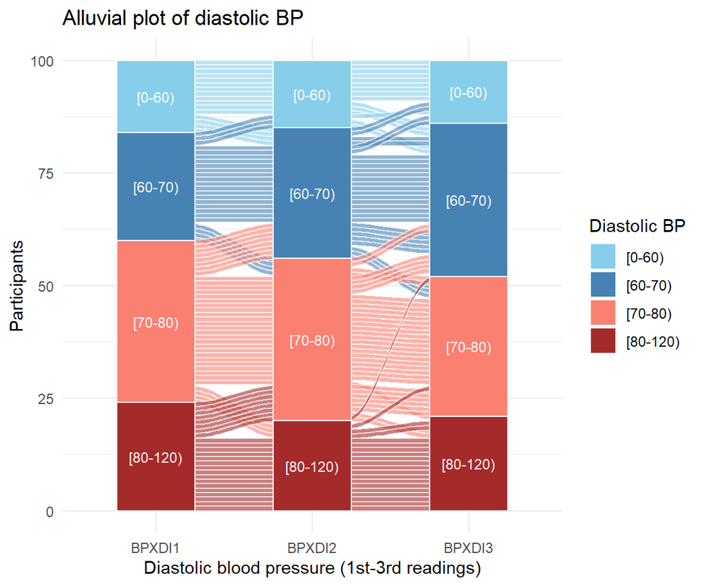

```r
# Alluvial plot (do not forget to add a fourth color and adapt the text!)
ggplot(bp_long,
       aes(x = Reading,
           stratum = Diastolic_BP,
           alluvium = SEQN,
           fill = Diastolic_BP,
           label = Diastolic_BP)) +
  geom_flow(stat = "alluvium", lode.guidance = "forward", alpha = 0.6, color = "white") +
  geom_stratum(width = 0.5, color = "white") +
  geom_text(stat = "stratum", size = 3, color = "white") +
  scale_fill_manual(values = c("skyblue", "steelblue", "salmon",  "brown")) +
  theme_minimal() +
  labs(title = "Alluvial plot of diastolic BP",
       x = "Diastolic blood pressure (1st-3rd readings)",
       y = "Participants",
       fill = "Diastolic BP")
```

## 4.5 Exercise 5

☑️ Exercise 5:

```r
results_directory <- "C:/GitHub/rforphysicians/docs/plots/" # your results directory here

jpeg(file = paste0(results_directory,"boxplots_bp_by_gender.jpeg"),
     width = 10,
     height = 6,
     units = "in",
     res=100)

par(mfrow=c(1,3))
boxplot(merged_nhanes$BPXSY1 ~ merged_nhanes$RIAGENDR,
        names = c("Male", "Female"),
        xlab = "Gender",
        ylab = "Systolic blood pressure (1st reading) [mmHg]",
        main = "BP (1st reading)",
        col = c("salmon", "skyblue"))
boxplot(merged_nhanes$BPXSY2 ~ merged_nhanes$RIAGENDR,
        names = c("Male", "Female"),
        xlab = "Gender",
        ylab = "Systolic blood pressure (2nd reading) [mmHg]",
        main = "BP (2nd reading)",
        col = c("salmon", "skyblue"))
boxplot(merged_nhanes$BPXSY3 ~ merged_nhanes$RIAGENDR,
        names = c("Male", "Female"),
        xlab = "Gender",
        ylab = "Systolic blood pressure (3rd reading) [mmHg]",
        main = "BP (3rd reading)",
        col = c("salmon", "skyblue"))

dev.off()
par(mfrow=c(1,1))
```

## 4.6 Exercise 6

☑️ Exercise 6:

```r
results_directory <- "C:/GitHub/rforphysicians/docs/plots/" # your results directory here

bar_plot_med_bmi_by_gender <- grid.arrange(plot1, plot2, ncol=2)
ggsave(filename = "bar_plot_med_bmi_by_gender.png",
  plot = bar_plot_med_bmi_by_gender,
  bg = 'white',
  width = 10,
  height = 6,
  units = c("in"),
  path = results_directory)
```

# References

Alexander Henzi. 2021. “Programming and Data Analysis with R.” Lecture notes.

Burns, Patrick. n.d. *The R Inferno*. Accessed May 8, 2025. https://www.burns-stat.com/documents/books/the-r-inferno/.

CDC. 2025. “National Death Index.” *Data Linkage*. https://www.cdc.gov/nchs/linked-data/mortality-files/index.html.

“ChatGPT.” n.d. Accessed January 26, 2025. https://chatgpt.com.

Christopher J. Endres. 2025. “Introducing nhanesA.” https://cran.r-project.org/web/packages/nhanesA/vignettes/Introducing_nhanesA.html.

“Create Elegant Data Visualisations Using the Grammar of Graphics.” n.d. Accessed January 26, 2025. https://ggplot2.tidyverse.org/.

David, Author. 2016. “BIRT Joins.” *MBSE Chaos*. https://mbsechaos.wordpress.com/2016/05/24/birt-joins/.

Elena Kosourova. n.d. “RStudio Tutorial for Beginners: A Complete Guide.” Accessed January 26, 2025. https://www.datacamp.com/tutorial/r-studio-tutorial.

Ghasemi, Asghar, and Saleh Zahediasl. 2012. “Normality Tests for Statistical Analysis: A Guide for Non-Statisticians.” *International Journal of Endocrinology and Metabolism* 10 (2): 486–89. https://doi.org/10.5812/ijem.3505.

Grolemund, Hadley Wickham and Garrett. n.d. *R for Data Science*. Accessed May 8, 2025. https://r4ds.had.co.nz/introduction.html.

Mayer, Michael. 2025. “Mayer79/Statistical_computing_material.” https://github.com/mayer79/statistical_computing_material.

Patrick Burns. n.d. *Impatient R*. Accessed May 8, 2025. https://www.burns-stat.com/documents/tutorials/impatient-r/.

“*P*-Value.” 2025. *Wikipedia*. https://en.wikipedia.org/w/index.php?title=P-value&oldid=1305292611.

“Synthetic Dataset for AI in Healthcare.” n.d. Accessed May 9, 2025. https://www.kaggle.com/datasets/smmmmmmmmmmmm/synthetic-dataset-for-ai-in-healthcare.

“The Comprehensive R Archive Network.” n.d. Accessed January 26, 2025. https://stat.ethz.ch/CRAN/.

W. N. Venables, D. M. Smith and the R Core Team. n.d. “An Introduction to R.” Accessed May 8, 2025. https://cran.r-project.org/doc/manuals/r-release/R-intro.html.

Wickham, Hadley. n.d. *Advanced R*. Accessed May 8, 2025. https://adv-r.hadley.nz/introduction.html.